# EDA Pemilihan Model Klorofil-a Selat Sunda V2

Rafi Adabhi Sunarya

2026-10-14

```r
knitr::opts_chunk$set(
  echo = TRUE,
  message = FALSE,
  warning = FALSE,
  fig.align = "center",
  out.width = "100%"
)

options(scipen = 999, dplyr.summarise.inform = FALSE)

required_packages <- c(
  "tidyverse", "lubridate", "patchwork", "spdep", "igraph",
  "tseries", "zoo", "knitr", "scales"
)

missing_packages <- required_packages[
  !vapply(required_packages, requireNamespace, logical(1), quietly = TRUE)
]
if (length(missing_packages) > 0) {
  stop(
    "Instal paket berikut terlebih dahulu: ",
    paste(missing_packages, collapse = ", ")
  )
}

library(tidyverse)
library(lubridate)
library(patchwork)
library(spdep)
library(igraph)
library(tseries)
library(zoo)
library(knitr)
library(scales)
theme_set(theme_minimal(base_size = 11))

ROOT <- "D:/thesis"
PANEL_PATH <- file.path(
  ROOT, "data", "processed", "model_dataset",
  "selat_sunda_monthly_panel_200301_202512_v1.csv"
)
TABLE_DIR <- file.path(ROOT, "output", "tables", "eda_gstarx_v2")
dir.create(TABLE_DIR, recursive = TRUE, showWarnings = FALSE)

TRAIN_END <- as.Date("2020-12-01")
VALIDATION_START <- as.Date("2021-01-01")
VALIDATION_END <- as.Date("2022-12-01")
GRID_STEP <- 0.25
NSIM_MORAN <- 199
```

# Data

```r
required_columns <- c(
  "month", "grid_id", "lon", "lat", "chla_mg_m3", "sst_c",
  "sst_anomaly_c", "u10_m_s", "v10_m_s", "wind_speed_m_s"
)

panel <- readr::read_csv(
  PANEL_PATH,
  show_col_types = FALSE,
  progress = FALSE
)

missing_columns <- setdiff(required_columns, names(panel))
if (length(missing_columns) > 0) {
  stop("Kolom tidak ditemukan: ", paste(missing_columns, collapse = ", "))
}

panel <- panel %>%
  transmute(
    month = as.Date(month),
    grid_id = as.character(grid_id),
    lon = as.numeric(lon),
    lat = as.numeric(lat),
    chla_mg_m3 = as.numeric(chla_mg_m3),
    sst_c = as.numeric(sst_c),
    sst_anomaly_c = as.numeric(sst_anomaly_c),
    u10_m_s = as.numeric(u10_m_s),
    v10_m_s = as.numeric(v10_m_s),
    wind_speed_m_s = as.numeric(wind_speed_m_s)
  ) %>%
  arrange(month, grid_id) %>%
  mutate(
    chla_observed = is.finite(chla_mg_m3),
    log_chla = if_else(chla_mg_m3 > 0, log(chla_mg_m3), NA_real_),
    calendar_month = month(month),
    year = year(month)
  )

if (anyNA(panel$month)) stop("Kolom month tidak berhasil dibaca sebagai tanggal.")
if (anyDuplicated(panel[c("month", "grid_id")])) {
  stop("Ada kombinasi month dan grid_id yang duplikat.")
}

n_grid <- n_distinct(panel$grid_id)
n_month <- n_distinct(panel$month)

if (nrow(panel) != n_grid * n_month) {
  stop("Panel belum memiliki seluruh kombinasi grid dan bulan.")
}

data_overview <- tibble(
  ukuran_panel = nrow(panel),
  jumlah_grid = n_grid,
  jumlah_bulan = n_month,
  periode_awal = min(panel$month),
  periode_akhir = max(panel$month),
  chla_tersedia = mean(panel$chla_observed),
  sst_tersedia = mean(is.finite(panel$sst_c)),
  angin_tersedia = mean(is.finite(panel$u10_m_s) & is.finite(panel$v10_m_s))
)

knitr::kable(data_overview, digits = 3)
```

| ukuran_panel | jumlah_grid | jumlah_bulan | periode_awal | periode_akhir | chla_tersedia | sst_tersedia | angin_tersedia |
| --- | --- | --- | --- | --- | --- | --- | --- |
| 40848 | 148 | 276 | 2003-01-01 | 2025-12-01 | 0.972 | 1 | 1 |

# Kelengkapan Data

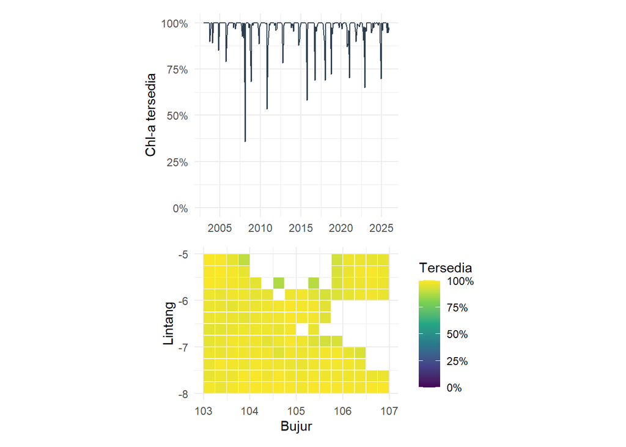

```r
monthly_summary <- panel %>%
  group_by(month) %>%
  summarise(
    n_grid = n(),
    n_chla = sum(chla_observed),
    availability = mean(chla_observed),
    chla_mean = mean(chla_mg_m3, na.rm = TRUE),
    chla_median = median(chla_mg_m3, na.rm = TRUE),
    sst_mean = mean(sst_c, na.rm = TRUE),
    wind_speed_mean = mean(wind_speed_m_s, na.rm = TRUE),
    .groups = "drop"
  )

grid_summary <- panel %>%
  group_by(grid_id) %>%
  summarise(
    lon = first(lon),
    lat = first(lat),
    n_month = n(),
    n_chla = sum(chla_observed),
    availability = mean(chla_observed),
    chla_mean = mean(chla_mg_m3, na.rm = TRUE),
    chla_median = median(chla_mg_m3, na.rm = TRUE),
    chla_sd = sd(chla_mg_m3, na.rm = TRUE),
    .groups = "drop"
  )

write_csv(monthly_summary, file.path(TABLE_DIR, "monthly_summary_v2.csv"))
write_csv(grid_summary, file.path(TABLE_DIR, "grid_summary_v2.csv"))

p_availability_time <- ggplot(monthly_summary, aes(month, availability)) +
  geom_line(linewidth = 0.45, colour = "#2C3E50") +
  scale_y_continuous(labels = percent_format(accuracy = 1), limits = c(0, 1)) +
  labs(x = NULL, y = "Chl-a tersedia")

p_availability_map <- ggplot(grid_summary, aes(lon, lat, fill = availability)) +
  geom_tile(width = GRID_STEP * 0.94, height = GRID_STEP * 0.94) +
  coord_equal() +
  scale_fill_viridis_c(labels = percent_format(accuracy = 1), limits = c(0, 1)) +
  labs(x = "Bujur", y = "Lintang", fill = "Tersedia")

p_availability_time / p_availability_map
```

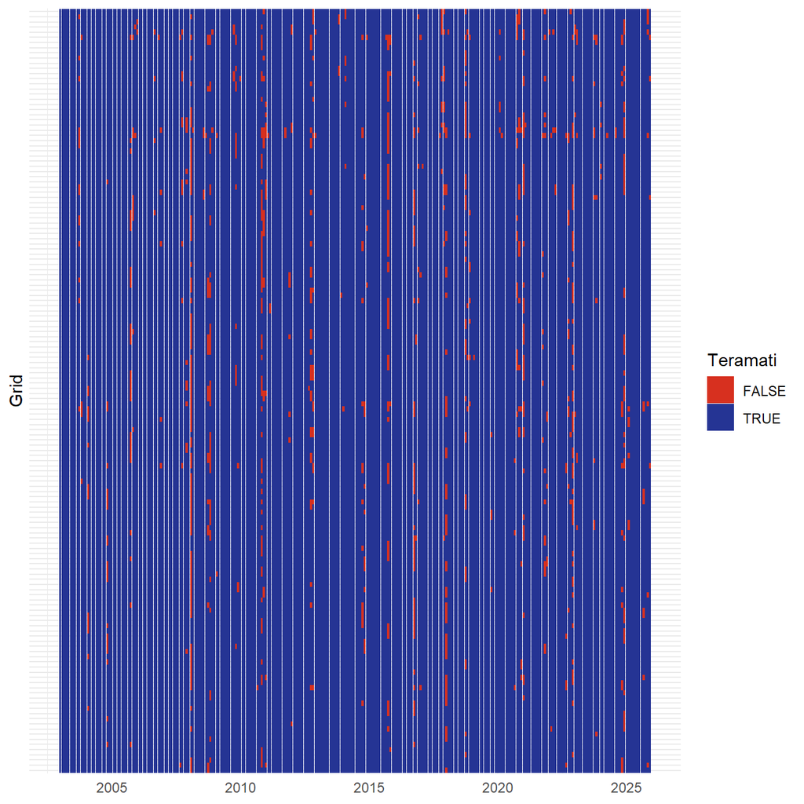

```r
grid_order <- grid_summary %>%
  arrange(lat, lon) %>%
  pull(grid_id)

panel %>%
  mutate(grid_plot = factor(grid_id, levels = grid_order)) %>%
  ggplot(aes(month, grid_plot, fill = chla_observed)) +
  geom_tile() +
  scale_fill_manual(values = c(`TRUE` = "#253494", `FALSE` = "#D7301F")) +
  labs(x = NULL, y = "Grid", fill = "Teramati") +
  theme(axis.text.y = element_blank(), axis.ticks.y = element_blank())
```

# Distribusi Klorofil-a

```r
bulan_terburuk <- monthly_summary %>%
  arrange(availability) %>%
  slice_head(n = 5) %>%
  transmute(month, grid_tanpa_chla = n_grid - n_chla,
            tersedia_persen = round(100 * availability, 1))
knitr::kable(bulan_terburuk)
```

| month | grid_tanpa_chla | tersedia_persen |
| --- | --- | --- |
| 2008-02-01 | 95 | 35.8 |
| 2010-11-01 | 69 | 53.4 |
| 2015-10-01 | 62 | 58.1 |
| 2022-12-01 | 52 | 64.9 |
| 2008-11-01 | 47 | 68.2 |

```r
cat(if (min(monthly_summary$availability) < 0.8) {
  "Ada bulan dengan lebih dari 20% grid tanpa Chl-a. Nilai tengah regional pada bulan itu perlu dibaca bersama peta grid yang tersedia; agregasi bulanan belum menghapus seluruh missing."
} else {
  "Seluruh bulan memiliki sedikitnya 80% grid dengan Chl-a. Missing bulanan tetap dicatat saat model dievaluasi."
})
```

```
## Ada bulan dengan lebih dari 20% grid tanpa Chl-a. Nilai tengah regional pada bulan itu perlu dibaca bersama peta grid yang tersedia; agregasi bulanan belum menghapus seluruh missing.
```

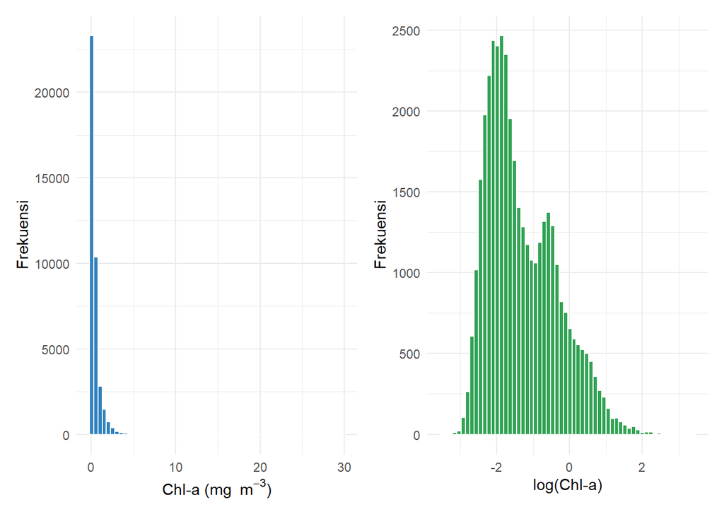

```r
p_raw <- panel %>%
  filter(chla_mg_m3 > 0) %>%
  ggplot(aes(chla_mg_m3)) +
  geom_histogram(bins = 60, fill = "#3182BD", colour = "white") +
  labs(x = expression("Chl-a (mg "~m^{-3}*")"), y = "Frekuensi")

p_log <- panel %>%
  filter(is.finite(log_chla)) %>%
  ggplot(aes(log_chla)) +
  geom_histogram(bins = 60, fill = "#31A354", colour = "white") +
  labs(x = "log(Chl-a)", y = "Frekuensi")

p_raw + p_log
```

```r
sample_skewness <- function(x) {
  x <- x[is.finite(x)]
  mean((x - mean(x))^3) / sd(x)^3
}

target_quantiles <- panel %>%
  summarise(
    minimum = min(chla_mg_m3, na.rm = TRUE),
    q01 = quantile(chla_mg_m3, 0.01, na.rm = TRUE),
    median = median(chla_mg_m3, na.rm = TRUE),
    q99 = quantile(chla_mg_m3, 0.99, na.rm = TRUE),
    maximum = max(chla_mg_m3, na.rm = TRUE),
    skew_raw = sample_skewness(chla_mg_m3),
    skew_log = sample_skewness(log_chla)
  )

knitr::kable(target_quantiles, digits = 4)
```

| minimum | q01 | median | q99 | maximum | skew_raw | skew_log |
| --- | --- | --- | --- | --- | --- | --- |
| 0.0303 | 0.0644 | 0.2139 | 3.5211 | 29.7823 | 7.8542 | 0.7477 |

# Pola Temporal dan Musiman

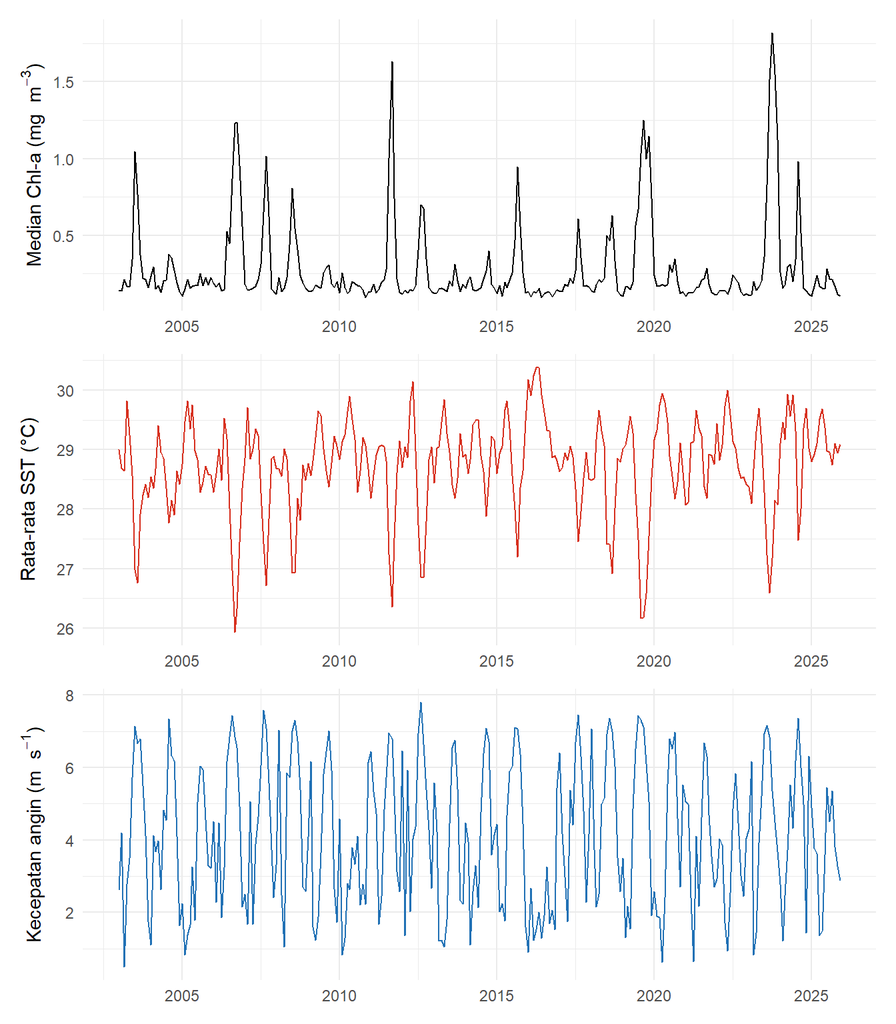

```r
p_chla_time <- ggplot(monthly_summary, aes(month, chla_median)) +
  geom_line(linewidth = 0.45, colour = "black") +
  labs(x = NULL, y = expression("Median Chl-a (mg "~m^{-3}*")"))

p_sst_time <- ggplot(monthly_summary, aes(month, sst_mean)) +
  geom_line(linewidth = 0.45, colour = "#D7301F") +
  labs(x = NULL, y = "Rata-rata SST (°C)")

p_wind_time <- ggplot(monthly_summary, aes(month, wind_speed_mean)) +
  geom_line(linewidth = 0.45, colour = "#2171B5") +
  labs(x = NULL, y = expression("Kecepatan angin (m "~s^{-1}*")"))

p_chla_time / p_sst_time / p_wind_time
```

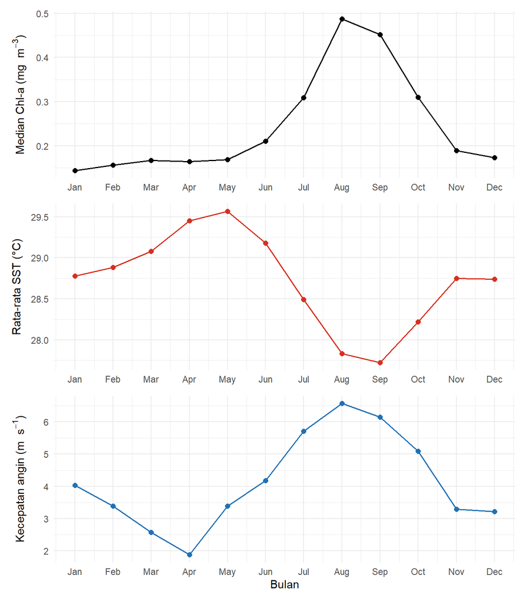

```r
seasonal_summary <- panel %>%
  group_by(calendar_month) %>%
  summarise(
    chla_median = median(chla_mg_m3, na.rm = TRUE),
    sst_mean = mean(sst_c, na.rm = TRUE),
    wind_speed_mean = mean(wind_speed_m_s, na.rm = TRUE),
    .groups = "drop"
  )

month_labels <- month.abb

p_chla_season <- ggplot(seasonal_summary, aes(calendar_month, chla_median)) +
  geom_line(linewidth = 0.6) +
  geom_point(size = 2) +
  scale_x_continuous(breaks = 1:12, labels = month_labels) +
  labs(x = NULL, y = expression("Median Chl-a (mg "~m^{-3}*")"))

p_sst_season <- ggplot(seasonal_summary, aes(calendar_month, sst_mean)) +
  geom_line(linewidth = 0.6, colour = "#D7301F") +
  geom_point(size = 2, colour = "#D7301F") +
  scale_x_continuous(breaks = 1:12, labels = month_labels) +
  labs(x = NULL, y = "Rata-rata SST (°C)")

p_wind_season <- ggplot(seasonal_summary, aes(calendar_month, wind_speed_mean)) +
  geom_line(linewidth = 0.6, colour = "#2171B5") +
  geom_point(size = 2, colour = "#2171B5") +
  scale_x_continuous(breaks = 1:12, labels = month_labels) +
  labs(x = "Bulan", y = expression("Kecepatan angin (m "~s^{-1}*")"))

p_chla_season / p_sst_season / p_wind_season
```

# Pola Spasial

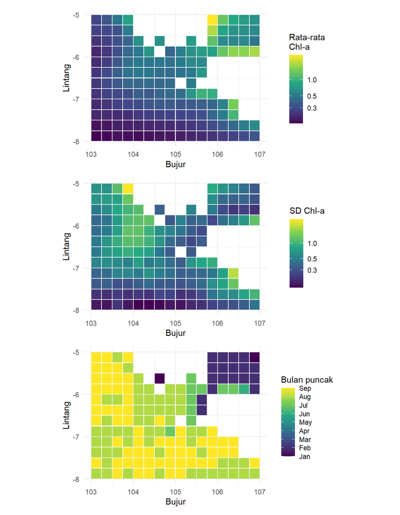

```r
grid_month_summary <- panel %>%
  group_by(grid_id, lon, lat, calendar_month) %>%
  summarise(chla_median = median(chla_mg_m3, na.rm = TRUE), .groups = "drop")

peak_month <- grid_month_summary %>%
  group_by(grid_id) %>%
  slice_max(chla_median, n = 1, with_ties = FALSE) %>%
  ungroup() %>%
  select(grid_id, peak_month = calendar_month)

grid_summary <- grid_summary %>%
  left_join(peak_month, by = "grid_id")

write_csv(grid_summary, file.path(TABLE_DIR, "grid_spatial_summary_v2.csv"))

p_spatial_mean <- ggplot(grid_summary, aes(lon, lat, fill = chla_mean)) +
  geom_tile(width = GRID_STEP * 0.94, height = GRID_STEP * 0.94) +
  coord_equal() +
  scale_fill_viridis_c(trans = "log10") +
  labs(x = "Bujur", y = "Lintang", fill = "Rata-rata\nChl-a")

p_spatial_sd <- ggplot(grid_summary, aes(lon, lat, fill = chla_sd)) +
  geom_tile(width = GRID_STEP * 0.94, height = GRID_STEP * 0.94) +
  coord_equal() +
  scale_fill_viridis_c(trans = "log10") +
  labs(x = "Bujur", y = "Lintang", fill = "SD Chl-a")

p_peak_month <- ggplot(grid_summary, aes(lon, lat, fill = peak_month)) +
  geom_tile(width = GRID_STEP * 0.94, height = GRID_STEP * 0.94) +
  coord_equal() +
  scale_fill_viridis_c(breaks = 1:12, labels = month_labels) +
  labs(x = "Bujur", y = "Lintang", fill = "Bulan puncak")

p_spatial_mean / p_spatial_sd / p_peak_month
```

# Seasonal Adjustment

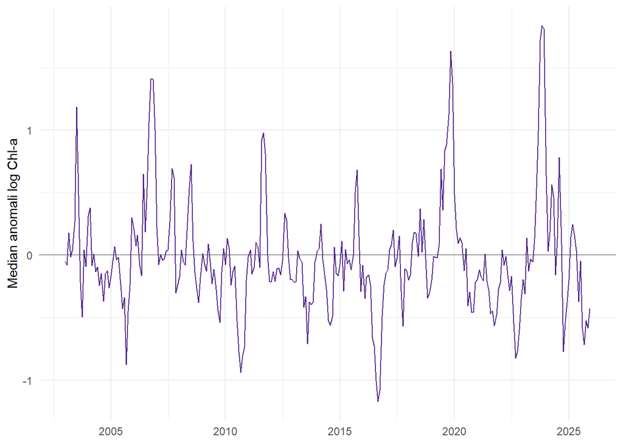

```r
climatology <- panel %>%
  filter(month <= TRAIN_END) %>%
  group_by(grid_id, calendar_month) %>%
  summarise(
    climatology_log_chla = mean(log_chla, na.rm = TRUE),
    climatology_u10 = mean(u10_m_s, na.rm = TRUE),
    climatology_v10 = mean(v10_m_s, na.rm = TRUE),
    climatology_wind_speed = mean(wind_speed_m_s, na.rm = TRUE),
    .groups = "drop"
  ) %>%
  mutate(
    across(
      starts_with("climatology_"),
      ~ if_else(is.nan(.x), NA_real_, .x)
    )
  )

panel <- panel %>%
  left_join(climatology, by = c("grid_id", "calendar_month")) %>%
  mutate(
    log_chla_anom = log_chla - climatology_log_chla,
    u10_anom = u10_m_s - climatology_u10,
    v10_anom = v10_m_s - climatology_v10,
    wind_speed_anom = wind_speed_m_s - climatology_wind_speed
  )

regional_anomaly <- panel %>%
  group_by(month) %>%
  summarise(
    median_log_chla_anom = median(log_chla_anom, na.rm = TRUE),
    .groups = "drop"
  )

ggplot(regional_anomaly, aes(month, median_log_chla_anom)) +
  geom_hline(yintercept = 0, colour = "grey60") +
  geom_line(linewidth = 0.45, colour = "#54278F") +
  labs(x = NULL, y = "Median anomali log Chl-a")
```

# Stasioneritas

```r
fill_for_test <- function(x) {
  x <- zoo::na.approx(x, na.rm = FALSE, maxgap = 6)
  x <- zoo::na.locf(x, na.rm = FALSE)
  x <- zoo::na.locf(x, na.rm = FALSE, fromLast = TRUE)
  if (anyNA(x)) x[is.na(x)] <- median(x, na.rm = TRUE)
  x
}

stationarity <- panel %>%
  arrange(grid_id, month) %>%
  group_by(grid_id) %>%
  group_modify(~ {
    x <- fill_for_test(.x$log_chla_anom)
    adf_p <- tryCatch(
      suppressWarnings(tseries::adf.test(x)$p.value),
      error = function(e) NA_real_
    )
    kpss_p <- tryCatch(
      suppressWarnings(tseries::kpss.test(x, null = "Level")$p.value),
      error = function(e) NA_real_
    )
    tibble(adf_p = adf_p, kpss_p = kpss_p)
  }) %>%
  ungroup()

stationarity_summary <- stationarity %>%
  summarise(
    grid_adf_menolak_unit_root = mean(adf_p < 0.05, na.rm = TRUE),
    grid_kpss_tidak_menolak_stasioner = mean(kpss_p >= 0.05, na.rm = TRUE)
  )

write_csv(stationarity, file.path(TABLE_DIR, "stationarity_by_grid_v2.csv"))
knitr::kable(stationarity_summary, digits = 3)
```

| grid_adf_menolak_unit_root | grid_kpss_tidak_menolak_stasioner |
| --- | --- |
| 1 | 0.973 |

# Matriks Bobot Spasial

```r
coordinates <- panel %>%
  distinct(grid_id, lon, lat) %>%
  arrange(grid_id)

dx <- abs(outer(coordinates$lon, coordinates$lon, "-"))
dy <- abs(outer(coordinates$lat, coordinates$lat, "-"))
tolerance <- 1e-8

adjacency <- (
  (abs(dx - GRID_STEP) < tolerance & dy < tolerance) |
    (abs(dy - GRID_STEP) < tolerance & dx < tolerance)
) * 1

diag(adjacency) <- 0
rownames(adjacency) <- coordinates$grid_id
colnames(adjacency) <- coordinates$grid_id

neighbor_count <- rowSums(adjacency)
W <- adjacency
has_neighbor <- neighbor_count > 0
W[has_neighbor, ] <- W[has_neighbor, , drop = FALSE] / neighbor_count[has_neighbor]

grid_graph <- igraph::graph_from_adjacency_matrix(
  adjacency,
  mode = "undirected",
  diag = FALSE
)
graph_components <- igraph::components(grid_graph)

weight_summary <- tibble(
  jumlah_grid = nrow(coordinates),
  jumlah_hubungan = sum(adjacency) / 2,
  minimum_tetangga = min(neighbor_count),
  median_tetangga = median(neighbor_count),
  maksimum_tetangga = max(neighbor_count),
  grid_tanpa_tetangga = sum(neighbor_count == 0),
  komponen_terpisah = graph_components$no
)

weight_table <- as.data.frame(W) %>%
  tibble::rownames_to_column("grid_id")

write_csv(weight_table, file.path(TABLE_DIR, "spatial_weight_rook_v2.csv"))
knitr::kable(weight_summary)
```

| jumlah_grid | jumlah_hubungan | minimum_tetangga | median_tetangga | maksimum_tetangga | grid_tanpa_tetangga | komponen_terpisah |
| --- | --- | --- | --- | --- | --- | --- |
| 148 | 253 | 0 | 4 | 4 | 1 | 2 |

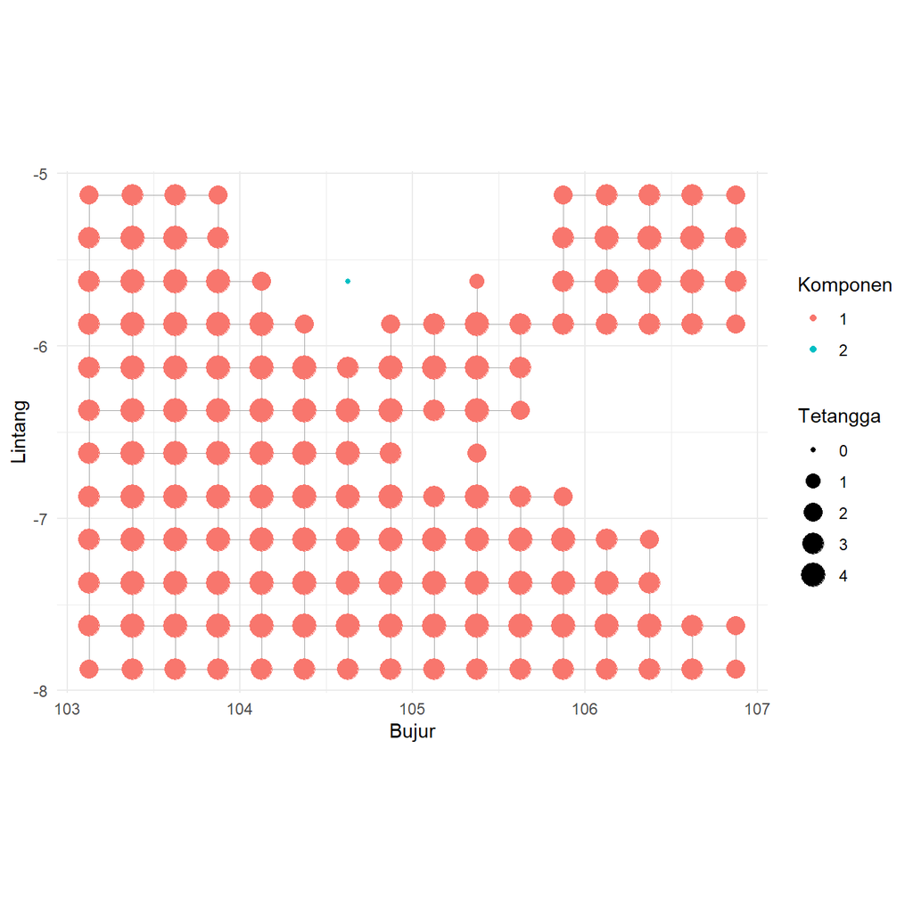

```r
edge_index <- which(upper.tri(adjacency) & adjacency == 1, arr.ind = TRUE)

edge_data <- tibble(
  lon = coordinates$lon[edge_index[, 1]],
  lat = coordinates$lat[edge_index[, 1]],
  lon_end = coordinates$lon[edge_index[, 2]],
  lat_end = coordinates$lat[edge_index[, 2]]
)

coordinate_plot <- coordinates %>%
  mutate(
    neighbor_count = neighbor_count,
    component = factor(graph_components$membership)
  )

ggplot() +
  geom_segment(
    data = edge_data,
    aes(lon, lat, xend = lon_end, yend = lat_end),
    linewidth = 0.25,
    colour = "grey65"
  ) +
  geom_point(
    data = coordinate_plot,
    aes(lon, lat, colour = component, size = neighbor_count)
  ) +
  coord_equal() +
  labs(x = "Bujur", y = "Lintang", colour = "Komponen", size = "Tetangga")
```

# Spatial Lag

```r
wide_anomaly <- panel %>%
  select(month, grid_id, log_chla_anom) %>%
  pivot_wider(names_from = grid_id, values_from = log_chla_anom) %>%
  arrange(month)

anomaly_matrix <- wide_anomaly %>%
  select(all_of(coordinates$grid_id)) %>%
  as.matrix()

observed_matrix <- is.finite(anomaly_matrix) * 1
anomaly_zero <- anomaly_matrix
anomaly_zero[!is.finite(anomaly_zero)] <- 0

spatial_numerator <- anomaly_zero %*% t(W)
spatial_denominator <- observed_matrix %*% t(W)
spatial_lag_matrix <- spatial_numerator / spatial_denominator
spatial_lag_matrix[spatial_denominator == 0] <- NA_real_

spatial_lag_long <- as_tibble(spatial_lag_matrix) %>%
  mutate(month = wide_anomaly$month, .before = 1) %>%
  pivot_longer(
    -month,
    names_to = "grid_id",
    values_to = "w_log_chla_anom"
  )

panel <- panel %>%
  left_join(spatial_lag_long, by = c("month", "grid_id")) %>%
  arrange(grid_id, month) %>%
  group_by(grid_id) %>%
  mutate(
    own_lag1 = lag(log_chla_anom, 1),
    own_lag2 = lag(log_chla_anom, 2),
    own_lag12 = lag(log_chla_anom, 12),
    spatial_lag1 = lag(w_log_chla_anom, 1)
  ) %>%
  ungroup()
```

# Moran’s I Bulanan

```r
moran_one <- function(data, value, nsim = NSIM_MORAN) {
  x <- data[[value]][match(coordinates$grid_id, data$grid_id)]
  keep <- is.finite(x)
  adjacency_sub <- adjacency[keep, keep, drop = FALSE]

  if (sum(keep) < 10 || sum(adjacency_sub) == 0) {
    return(tibble(moran_i = NA_real_, p_value = NA_real_, n = sum(keep)))
  }

  listw_sub <- spdep::mat2listw(
    adjacency_sub,
    row.names = coordinates$grid_id[keep],
    style = "W",
    zero.policy = TRUE
  )

  test <- spdep::moran.mc(
    x[keep],
    listw = listw_sub,
    nsim = nsim,
    zero.policy = TRUE,
    alternative = "greater"
  )

  tibble(
    moran_i = unname(test$statistic),
    p_value = test$p.value,
    n = sum(keep)
  )
}
```

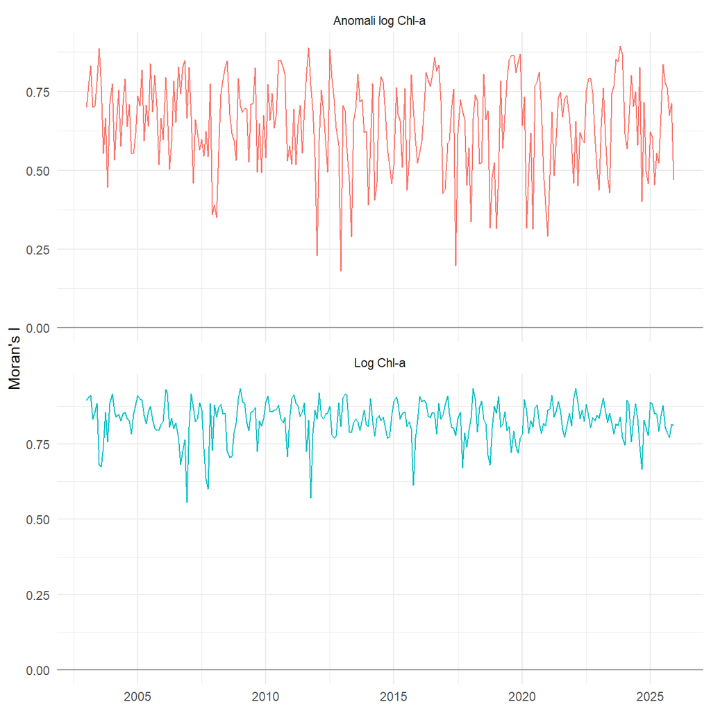

```r
set.seed(20260918)

moran_raw <- panel %>%
  group_by(month) %>%
  group_modify(~ moran_one(.x, "log_chla")) %>%
  ungroup() %>%
  mutate(series = "Log Chl-a")

moran_anomaly <- panel %>%
  group_by(month) %>%
  group_modify(~ moran_one(.x, "log_chla_anom")) %>%
  ungroup() %>%
  mutate(series = "Anomali log Chl-a")

moran_monthly <- bind_rows(moran_raw, moran_anomaly)

moran_summary <- moran_monthly %>%
  group_by(series) %>%
  summarise(
    median_moran_i = median(moran_i, na.rm = TRUE),
    q25 = quantile(moran_i, 0.25, na.rm = TRUE),
    q75 = quantile(moran_i, 0.75, na.rm = TRUE),
    proporsi_positif = mean(moran_i > 0, na.rm = TRUE),
    proporsi_positif_signifikan = mean(moran_i > 0 & p_value < 0.05, na.rm = TRUE),
    .groups = "drop"
  )

write_csv(moran_monthly, file.path(TABLE_DIR, "monthly_moran_v2.csv"))
write_csv(moran_summary, file.path(TABLE_DIR, "moran_summary_v2.csv"))

ggplot(moran_monthly, aes(month, moran_i, colour = series)) +
  geom_hline(yintercept = 0, colour = "grey60") +
  geom_line(linewidth = 0.45) +
  facet_wrap(~ series, ncol = 1, scales = "free_y") +
  labs(x = NULL, y = "Moran's I", colour = NULL) +
  theme(legend.position = "none")
```

```r
knitr::kable(moran_summary, digits = 3)
```

| series | median_moran_i | q25 | q75 | proporsi_positif | proporsi_positif_signifikan |
| --- | --- | --- | --- | --- | --- |
| Anomali log Chl-a | 0.673 | 0.554 | 0.761 | 1 | 1 |
| Log Chl-a | 0.835 | 0.802 | 0.872 | 1 | 1 |

# Korelasi Antargrid

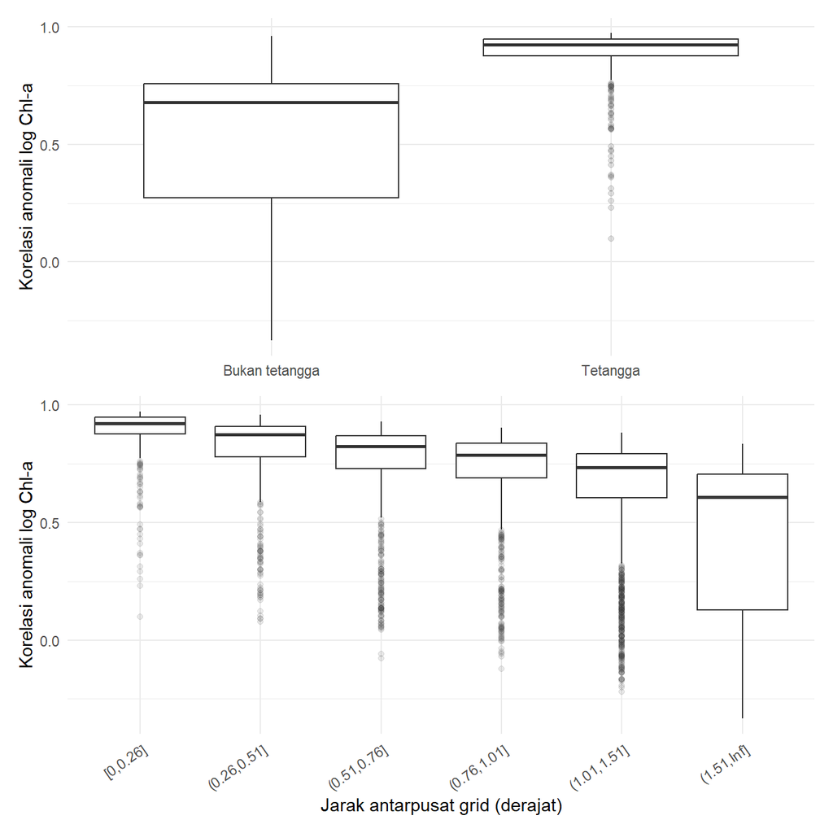

```r
correlation_matrix <- cor(anomaly_matrix, use = "pairwise.complete.obs")
distance_matrix <- sqrt(dx^2 + dy^2)
pair_index <- which(upper.tri(correlation_matrix), arr.ind = TRUE)

pairwise_correlation <- tibble(
  grid_1 = coordinates$grid_id[pair_index[, 1]],
  grid_2 = coordinates$grid_id[pair_index[, 2]],
  distance_degree = distance_matrix[pair_index],
  neighbor = adjacency[pair_index] == 1,
  correlation = correlation_matrix[pair_index]
) %>%
  filter(is.finite(correlation)) %>%
  mutate(
    distance_group = cut(
      distance_degree,
      breaks = c(0, 0.26, 0.51, 0.76, 1.01, 1.51, Inf),
      include.lowest = TRUE
    )
  )

write_csv(
  pairwise_correlation,
  file.path(TABLE_DIR, "pairwise_grid_correlation_v2.csv")
)

p_neighbor_correlation <- ggplot(
  pairwise_correlation,
  aes(factor(neighbor, labels = c("Bukan tetangga", "Tetangga")), correlation)
) +
  geom_boxplot(outlier.alpha = 0.15) +
  labs(x = NULL, y = "Korelasi anomali log Chl-a")

p_distance_correlation <- ggplot(
  pairwise_correlation,
  aes(distance_group, correlation)
) +
  geom_boxplot(outlier.alpha = 0.1) +
  labs(x = "Jarak antarpusat grid (derajat)", y = "Korelasi anomali log Chl-a") +
  theme(axis.text.x = element_text(angle = 35, hjust = 1))

p_neighbor_correlation / p_distance_correlation
```

# Autokorelasi Temporal

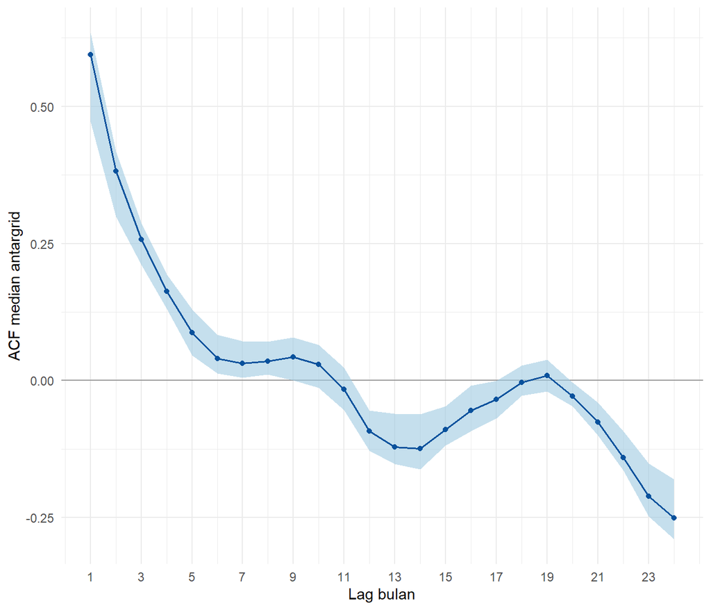

```r
temporal_acf <- panel %>%
  arrange(grid_id, month) %>%
  group_by(grid_id) %>%
  group_modify(~ {
    x <- .x$log_chla_anom
    tibble(
      lag = 1:24,
      acf = map_dbl(
        1:24,
        ~ cor(x, dplyr::lag(x, .x), use = "pairwise.complete.obs")
      )
    )
  }) %>%
  ungroup()

acf_summary <- temporal_acf %>%
  group_by(lag) %>%
  summarise(
    median_acf = median(acf, na.rm = TRUE),
    q25 = quantile(acf, 0.25, na.rm = TRUE),
    q75 = quantile(acf, 0.75, na.rm = TRUE),
    .groups = "drop"
  )

write_csv(acf_summary, file.path(TABLE_DIR, "temporal_acf_summary_v2.csv"))

ggplot(acf_summary, aes(lag, median_acf)) +
  geom_hline(yintercept = 0, colour = "grey60") +
  geom_ribbon(aes(ymin = q25, ymax = q75), fill = "#9ECAE1", alpha = 0.6) +
  geom_line(colour = "#08519C", linewidth = 0.7) +
  geom_point(colour = "#08519C", size = 1.4) +
  scale_x_continuous(breaks = seq(1, 24, 2)) +
  labs(x = "Lag bulan", y = "ACF median antargrid")
```

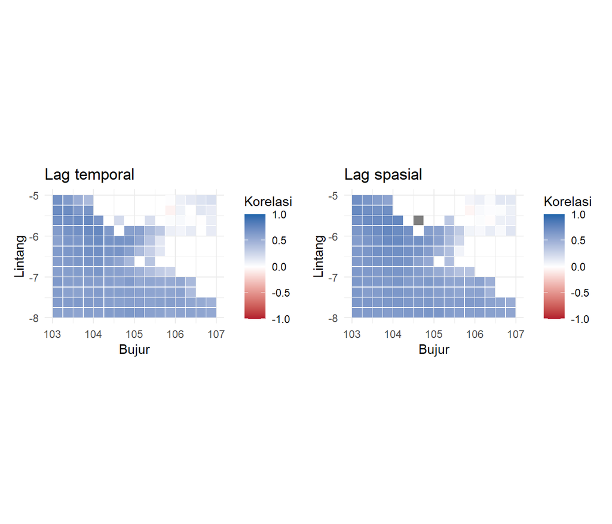

```r
lag_correlation_grid <- panel %>%
  group_by(grid_id) %>%
  summarise(
    lon = first(lon),
    lat = first(lat),
    own_lag1_correlation = cor(
      log_chla_anom,
      own_lag1,
      use = "pairwise.complete.obs"
    ),
    spatial_lag1_correlation = cor(
      log_chla_anom,
      spatial_lag1,
      use = "pairwise.complete.obs"
    ),
    .groups = "drop"
  )

write_csv(
  lag_correlation_grid,
  file.path(TABLE_DIR, "lag_correlation_by_grid_v2.csv")
)

p_own_lag <- ggplot(
  lag_correlation_grid,
  aes(lon, lat, fill = own_lag1_correlation)
) +
  geom_tile(width = GRID_STEP * 0.94, height = GRID_STEP * 0.94) +
  coord_equal() +
  scale_fill_gradient2(limits = c(-1, 1), low = "#B2182B", mid = "white", high = "#2166AC") +
  labs(x = "Bujur", y = "Lintang", fill = "Korelasi", title = "Lag temporal")

p_spatial_lag <- ggplot(
  lag_correlation_grid,
  aes(lon, lat, fill = spatial_lag1_correlation)
) +
  geom_tile(width = GRID_STEP * 0.94, height = GRID_STEP * 0.94) +
  coord_equal() +
  scale_fill_gradient2(limits = c(-1, 1), low = "#B2182B", mid = "white", high = "#2166AC") +
  labs(x = "Bujur", y = "Lintang", fill = "Korelasi", title = "Lag spasial")

p_own_lag + p_spatial_lag
```

# Hubungan Prediktor dengan Target Masa Depan

```r
predictor_names <- c("sst_anomaly_c", "u10_anom", "v10_anom")

future_correlation <- map_dfr(1:3, function(h) {
  horizon_data <- panel %>%
    arrange(grid_id, month) %>%
    group_by(grid_id) %>%
    mutate(target = lead(log_chla_anom, h)) %>%
    ungroup()

  map_dfr(predictor_names, function(predictor) {
    horizon_data %>%
      group_by(grid_id) %>%
      summarise(
        correlation = cor(
          target,
          .data[[predictor]],
          use = "pairwise.complete.obs"
        ),
        .groups = "drop"
      ) %>%
      summarise(
        median_correlation = median(correlation, na.rm = TRUE),
        q25 = quantile(correlation, 0.25, na.rm = TRUE),
        q75 = quantile(correlation, 0.75, na.rm = TRUE)
      ) %>%
      mutate(horizon = h, predictor = predictor, .before = 1)
  })
})

write_csv(
  future_correlation,
  file.path(TABLE_DIR, "future_predictor_correlation_v2.csv")
)

knitr::kable(future_correlation, digits = 3)
```

| horizon | predictor | median_correlation | q25 | q75 |
| --- | --- | --- | --- | --- |
| 1 | sst_anomaly_c | -0.533 | -0.574 | -0.451 |
| 1 | u10_anom | -0.306 | -0.337 | -0.226 |
| 1 | v10_anom | 0.386 | 0.310 | 0.426 |
| 2 | sst_anomaly_c | -0.406 | -0.443 | -0.317 |
| 2 | u10_anom | -0.220 | -0.252 | -0.178 |
| 2 | v10_anom | 0.298 | 0.234 | 0.344 |
| 3 | sst_anomaly_c | -0.284 | -0.325 | -0.228 |
| 3 | u10_anom | -0.193 | -0.220 | -0.157 |
| 3 | v10_anom | 0.256 | 0.195 | 0.295 |

# Perbandingan Model

Data latih berakhir pada Desember 2020. Validasi memakai Januari 2021 sampai Desember 2022. Periode 2023–2025 disimpan untuk pengujian akhir setelah model dipilih. Horizon 1, 2, dan 3 bulan diprediksi langsung dari informasi yang tersedia pada bulan asal ramalan.

Bagian EDA di atas menampilkan seluruh 2003–2025 untuk menggambarkan data. Karena itu periode uji sudah terlihat secara deskriptif. Kode pemilihan model di bawah hanya melatih sampai 2020 dan menghitung galat validasi sampai 2022; jangan memakai pola 2023–2025 yang terlihat di EDA untuk mengubah spesifikasi model.

```r
knitr::kable(data.frame(
  bagian = c("Latih", "Validasi", "Uji akhir"),
  awal = c("2003-01", "2021-01", "2023-01"),
  akhir = c("2020-12", "2022-12", "2025-12"),
  bulan = c(216, 24, 36)
))
```

| bagian | awal | akhir | bulan |
| --- | --- | --- | --- |
| Latih | 2003-01 | 2020-12 | 216 |
| Validasi | 2021-01 | 2022-12 | 24 |
| Uji akhir | 2023-01 | 2025-12 | 36 |

Tujuh pembanding dipakai: rerata musiman tiap grid, anomali bulan ini yang diteruskan ke bulan target, AR dengan efek grid, ARX dengan SST dan komponen angin, ARX ditambah lag spasial, ARX dengan koefisien terpisah per grid, serta versi lokal yang juga memakai lag spasial. Dua model dengan lag spasial adalah pemeriksaan awal, bukan estimasi GSTARX formal.

```r
model_names <- c("Musiman", "Persistensi", "AR", "ARX",
                 "ARX_spasial", "ARX_lokal", "ARX_lokal_spasial")

make_horizon <- function(h) {
  panel %>%
    arrange(grid_id, month) %>%
    group_by(grid_id) %>%
    mutate(
      target = lead(log_chla_anom, h),
      target_chla = lead(chla_mg_m3, h),
      target_month = lead(month, h),
      climatology_target = lead(climatology_log_chla, h)
    ) %>%
    ungroup() %>%
    transmute(
      origin_month = month, target_month, grid_id, target, target_chla,
      climatology_target, y_t = log_chla_anom, y_lag1 = own_lag1,
      y_lag12 = own_lag12, w_y_t = w_log_chla_anom,
      sst_t = sst_anomaly_c, u10_t = u10_anom, v10_t = v10_anom
    )
}

predict_local <- function(formula, training, validation) {
  output <- rep(NA_real_, nrow(validation))
  training_split <- split(training, training$grid_id)
  for (id in unique(validation$grid_id)) {
    idx <- which(validation$grid_id == id)
    sample_grid <- training_split[[id]]
    if (is.null(sample_grid) || nrow(sample_grid) < 48) next
    fit <- lm(formula, data = sample_grid)
    output[idx] <- suppressWarnings(
      predict(fit, newdata = validation[idx, , drop = FALSE])
    )
  }
  output
}

fit_horizon <- function(h) {
  all_data <- make_horizon(h)
  complete_data <- all_data %>%
    filter(complete.cases(target, target_chla, climatology_target, y_t,
                          y_lag1, y_lag12, w_y_t, sst_t, u10_t, v10_t))
  training <- complete_data %>% filter(target_month <= TRAIN_END)
  validation <- complete_data %>%
    filter(target_month >= VALIDATION_START,
           target_month <= VALIDATION_END)

  if (nrow(training) == 0 || nrow(validation) == 0) {
    stop("Data latih atau validasi kosong untuk horizon ", h)
  }
  if (!all(unique(validation$grid_id) %in% unique(training$grid_id))) {
    stop("Ada grid validasi tanpa riwayat latih pada horizon ", h)
  }

  fit_ar <- lm(target ~ y_t + y_lag1 + y_lag12 + factor(grid_id),
               data = training)
  fit_arx <- lm(target ~ y_t + y_lag1 + y_lag12 + sst_t + u10_t +
                  v10_t + factor(grid_id), data = training)
  fit_spasial <- lm(target ~ y_t + y_lag1 + y_lag12 + w_y_t +
                      sst_t + u10_t + v10_t + factor(grid_id),
                    data = training)

  prediksi <- validation %>%
    transmute(
      horizon = h, origin_month, target_month, grid_id,
      target, target_chla, climatology_target,
      Musiman = 0,
      Persistensi = y_t,
      AR = as.numeric(predict(fit_ar, newdata = validation)),
      ARX = as.numeric(predict(fit_arx, newdata = validation)),
      ARX_spasial = as.numeric(predict(fit_spasial, newdata = validation)),
      ARX_lokal = predict_local(
        target ~ y_t + y_lag1 + y_lag12 + sst_t + u10_t + v10_t,
        training, validation
      ),
      ARX_lokal_spasial = predict_local(
        target ~ y_t + y_lag1 + y_lag12 + w_y_t + sst_t + u10_t + v10_t,
        training, validation
      )
    )

  if (any(!is.finite(as.matrix(prediksi[model_names])))) {
    stop("Prediksi tidak lengkap pada horizon ", h,
         ". Periksa ukuran sampel dan rank model lokal.")
  }

  cakupan <- tibble(
    horizon = h,
    target_teramati = sum(
      is.finite(all_data$target) &
        all_data$target_month >= VALIDATION_START &
        all_data$target_month <= VALIDATION_END
    ),
    baris_dibandingkan = nrow(validation),
    grid_dibandingkan = n_distinct(validation$grid_id),
    grid_total = n_grid,
    bulan_validasi = n_distinct(validation$target_month)
  )

  list(prediksi = prediksi, cakupan = cakupan,
       koef_spasial = unname(coef(fit_spasial)["w_y_t"]))
}
```

```r
hasil_model <- purrr::map(1:3, fit_horizon)
names(hasil_model) <- as.character(1:3)
prediksi_lebar <- purrr::map_dfr(hasil_model, "prediksi")
cakupan <- purrr::map_dfr(hasil_model, "cakupan") %>%
  mutate(persen_dibandingkan = round(
    100 * baris_dibandingkan / target_teramati, 1
  ))

knitr::kable(cakupan)
```

| horizon | target_teramati | baris_dibandingkan | grid_dibandingkan | grid_total | bulan_validasi | persen_dibandingkan |
| --- | --- | --- | --- | --- | --- | --- |
| 1 | 3396 | 3085 | 147 | 148 | 24 | 90.8 |
| 2 | 3396 | 3083 | 147 | 148 | 24 | 90.8 |
| 3 | 3396 | 3073 | 147 | 148 | 24 | 90.5 |

```r
cat("Seluruh model dibandingkan pada baris yang sama. Grid tanpa tetangga rook dan baris dengan peubah asal yang kosong tidak ikut perbandingan ini. Persentase di tabel dihitung dari target validasi yang teramati, bukan seluruh grid-bulan.\n")
```

```
## Seluruh model dibandingkan pada baris yang sama. Grid tanpa tetangga rook dan baris dengan peubah asal yang kosong tidak ikut perbandingan ini. Persentase di tabel dihitung dari target validasi yang teramati, bukan seluruh grid-bulan.
```

```r
prediksi_panjang <- prediksi_lebar %>%
  pivot_longer(cols = all_of(model_names), names_to = "model",
               values_to = "pred_anom") %>%
  mutate(
    residu_log = target - pred_anom,
    pred_chla = exp(climatology_target + pred_anom),
    residu_chla = target_chla - pred_chla
  )

nilai_model <- prediksi_panjang %>%
  group_by(horizon, model) %>%
  summarise(
    n = n(),
    RMSE_log = sqrt(mean(residu_log^2)),
    MAE_log = mean(abs(residu_log)),
    RMSE_mg = sqrt(mean(residu_chla^2)),
    MAE_mg = mean(abs(residu_chla)),
    .groups = "drop"
  ) %>%
  mutate(model = factor(model, levels = model_names)) %>%
  arrange(horizon, RMSE_log)

write_csv(cakupan, file.path(TABLE_DIR, "cakupan_validasi_v2.csv"))
write_csv(nilai_model, file.path(TABLE_DIR, "metrik_validasi_v2.csv"))
write_csv(prediksi_panjang, file.path(TABLE_DIR, "prediksi_validasi_v2.csv"))

knitr::kable(nilai_model, digits = 4)
```

| horizon | model | n | RMSE_log | MAE_log | RMSE_mg | MAE_mg |
| --- | --- | --- | --- | --- | --- | --- |
| 1 | ARX_lokal_spasial | 3085 | 0.3322 | 0.2528 | 0.1801 | 0.0778 |
| 1 | ARX_lokal | 3085 | 0.3355 | 0.2551 | 0.1804 | 0.0781 |
| 1 | ARX_spasial | 3085 | 0.3359 | 0.2530 | 0.1887 | 0.0801 |
| 1 | ARX | 3085 | 0.3420 | 0.2572 | 0.1923 | 0.0818 |
| 1 | AR | 3085 | 0.3747 | 0.2870 | 0.1986 | 0.0906 |
| 1 | Persistensi | 3085 | 0.4023 | 0.3033 | 0.2443 | 0.0988 |
| 1 | Musiman | 3085 | 0.4934 | 0.3773 | 0.2133 | 0.1153 |
| 2 | ARX_lokal | 3083 | 0.3822 | 0.2958 | 0.2000 | 0.0901 |
| 2 | ARX_lokal_spasial | 3083 | 0.3836 | 0.2972 | 0.2003 | 0.0903 |
| 2 | ARX_spasial | 3083 | 0.3866 | 0.2951 | 0.2062 | 0.0927 |
| 2 | ARX | 3083 | 0.3886 | 0.2972 | 0.2070 | 0.0935 |
| 2 | AR | 3083 | 0.4301 | 0.3291 | 0.2142 | 0.1046 |
| 2 | Persistensi | 3083 | 0.4639 | 0.3592 | 0.2689 | 0.1154 |
| 2 | Musiman | 3083 | 0.4993 | 0.3834 | 0.2218 | 0.1180 |
| 3 | ARX_spasial | 3073 | 0.4170 | 0.3177 | 0.1991 | 0.0962 |
| 3 | ARX | 3073 | 0.4170 | 0.3178 | 0.1976 | 0.0960 |
| 3 | ARX_lokal | 3073 | 0.4173 | 0.3203 | 0.2042 | 0.0972 |
| 3 | ARX_lokal_spasial | 3073 | 0.4200 | 0.3223 | 0.2058 | 0.0981 |
| 3 | AR | 3073 | 0.4545 | 0.3456 | 0.2071 | 0.1066 |
| 3 | Persistensi | 3073 | 0.4999 | 0.3870 | 0.2531 | 0.1173 |
| 3 | Musiman | 3073 | 0.5021 | 0.3867 | 0.2197 | 0.1174 |

```r
cat("RMSE dan MAE log menilai anomali log Chl-a. Kolom mg/m3 menilai hasil setelah dikembalikan ke skala Chl-a. Jangan membandingkan angka log dengan angka mg/m3 secara langsung.\n")
```

```
## RMSE dan MAE log menilai anomali log Chl-a. Kolom mg/m3 menilai hasil setelah dikembalikan ke skala Chl-a. Jangan membandingkan angka log dengan angka mg/m3 secara langsung.
```

# Keuntungan Tambahan Setiap Komponen

Perbandingan berikut memakai pasangan yang hanya berbeda satu keputusan: memodelkan autoregresi, memasukkan SST dan angin, memakai koefisien lokal, atau menambahkan lag spasial. Ambang 2% dan kemenangan pada 60% bulan adalah aturan praktis untuk *screening*, bukan batas baku dalam oseanografi.

```r
bandingkan <- function(h, calon, acuan, pengulangan = 1000) {
  d <- hasil_model[[as.character(h)]]$prediksi
  kunci_bulan <- format(d$target_month, "%Y-%m")
  bulan_validasi <- sort(unique(kunci_bulan))
  a <- vapply(bulan_validasi, function(m) {
    i <- kunci_bulan == m
    sum((d$target[i] - d[[acuan]][i])^2)
  }, numeric(1))
  b <- vapply(bulan_validasi, function(m) {
    i <- kunci_bulan == m
    sum((d$target[i] - d[[calon]][i])^2)
  }, numeric(1))
  n <- vapply(bulan_validasi, function(m) sum(kunci_bulan == m), integer(1))
  gain <- function(idx) {
    100 * (1 - sqrt(sum(b[idx]) / sum(n[idx])) /
             sqrt(sum(a[idx]) / sum(n[idx])))
  }

  panjang_blok <- min(6L, length(bulan_validasi))
  starts <- seq_len(length(bulan_validasi) - panjang_blok + 1L)
  bootstrap <- replicate(pengulangan, {
    awal <- sample(starts, ceiling(length(bulan_validasi) / panjang_blok),
                   replace = TRUE)
    indeks <- unlist(lapply(awal, function(s) seq.int(s, length.out = panjang_blok)))
    gain(head(indeks, length(bulan_validasi)))
  })

  e_acuan <- abs(d$target_chla - exp(d$climatology_target + d[[acuan]]))
  e_calon <- abs(d$target_chla - exp(d$climatology_target + d[[calon]]))
  gain_mae_mg <- 100 * (mean(e_acuan) - mean(e_calon)) / mean(e_acuan)

  grid_gain <- d %>%
    mutate(sq_acuan = (target - .data[[acuan]])^2,
           sq_calon = (target - .data[[calon]])^2) %>%
    group_by(grid_id) %>%
    summarise(menang = mean(sq_calon) < mean(sq_acuan), .groups = "drop")

  tibble(
    horizon = h, acuan, calon,
    gain_RMSE_log_pct = gain(seq_along(n)),
    CI_bawah_pct = unname(quantile(bootstrap, 0.025)),
    CI_atas_pct = unname(quantile(bootstrap, 0.975)),
    bulan_menang_pct = 100 * mean(b / n < a / n),
    grid_menang_pct = 100 * mean(grid_gain$menang),
    gain_MAE_mg_pct = gain_mae_mg
  )
}

set.seed(20261014)
pasangan <- purrr::map_dfr(1:3, function(h) {
  skor <- nilai_model %>% filter(horizon == h)
  baseline <- skor %>%
    filter(as.character(model) %in% c("Musiman", "Persistensi")) %>%
    arrange(RMSE_log) %>%
    slice(1) %>%
    pull(model) %>%
    as.character()

  bind_rows(
    bandingkan(h, "AR", baseline),
    bandingkan(h, "ARX", "AR"),
    bandingkan(h, "ARX_spasial", "ARX"),
    bandingkan(h, "ARX_lokal", "ARX"),
    bandingkan(h, "ARX_lokal_spasial", "ARX_lokal"),
    bandingkan(h, "ARX", baseline),
    bandingkan(h, "ARX_spasial", baseline),
    bandingkan(h, "ARX_lokal", baseline),
    bandingkan(h, "ARX_lokal_spasial", baseline)
  )
}) %>%
  mutate(
    kuat = gain_RMSE_log_pct >= 2 & CI_bawah_pct > 0 &
      bulan_menang_pct >= 60 & gain_MAE_mg_pct >= 0,
    keputusan = if_else(kuat, "Layak diteruskan", "Belum mengalahkan acuan secara konsisten")
  )

write_csv(pasangan, file.path(TABLE_DIR, "perbandingan_berpasangan_v2.csv"))
knitr::kable(pasangan %>%
               mutate(across(c(gain_RMSE_log_pct, CI_bawah_pct, CI_atas_pct,
                               bulan_menang_pct, grid_menang_pct,
                               gain_MAE_mg_pct), ~ round(.x, 2))))
```

| horizon | acuan | calon | gain_RMSE_log_pct | CI_bawah_pct | CI_atas_pct | bulan_menang_pct | grid_menang_pct | gain_MAE_mg_pct | kuat | keputusan |
| --- | --- | --- | --- | --- | --- | --- | --- | --- | --- | --- |
| 1 | Persistensi | AR | 6.87 | -3.63 | 16.24 | 66.67 | 74.15 | 8.33 | FALSE | Belum mengalahkan acuan secara konsisten |
| 1 | AR | ARX | 8.72 | 2.25 | 14.76 | 83.33 | 87.07 | 9.65 | TRUE | Layak diteruskan |
| 1 | ARX | ARX_spasial | 1.79 | 0.25 | 2.36 | 79.17 | 66.67 | 2.09 | FALSE | Belum mengalahkan acuan secara konsisten |
| 1 | ARX | ARX_lokal | 1.91 | -0.47 | 5.17 | 37.50 | 52.38 | 4.58 | FALSE | Belum mengalahkan acuan secara konsisten |
| 1 | ARX_lokal | ARX_lokal_spasial | 0.97 | -0.31 | 1.32 | 66.67 | 55.10 | 0.35 | FALSE | Belum mengalahkan acuan secara konsisten |
| 1 | Persistensi | ARX | 14.99 | 7.96 | 24.33 | 87.50 | 87.07 | 17.17 | TRUE | Layak diteruskan |
| 1 | Persistensi | ARX_spasial | 16.51 | 9.80 | 24.78 | 87.50 | 87.07 | 18.91 | TRUE | Layak diteruskan |
| 1 | Persistensi | ARX_lokal | 16.62 | 12.06 | 23.64 | 87.50 | 88.44 | 20.97 | TRUE | Layak diteruskan |
| 1 | Persistensi | ARX_lokal_spasial | 17.43 | 12.93 | 23.43 | 91.67 | 88.44 | 21.25 | TRUE | Layak diteruskan |
| 2 | Persistensi | AR | 7.29 | -4.80 | 21.87 | 70.83 | 69.39 | 9.36 | FALSE | Belum mengalahkan acuan secara konsisten |
| 2 | AR | ARX | 9.65 | 2.47 | 14.53 | 70.83 | 90.48 | 10.67 | TRUE | Layak diteruskan |
| 2 | ARX | ARX_spasial | 0.52 | -0.39 | 1.12 | 58.33 | 60.54 | 0.84 | FALSE | Belum mengalahkan acuan secara konsisten |
| 2 | ARX | ARX_lokal | 1.66 | -2.53 | 4.33 | 37.50 | 59.18 | 3.65 | FALSE | Belum mengalahkan acuan secara konsisten |
| 2 | ARX_lokal | ARX_lokal_spasial | -0.39 | -1.40 | 0.58 | 25.00 | 45.58 | -0.30 | FALSE | Belum mengalahkan acuan secara konsisten |
| 2 | Persistensi | ARX | 16.24 | 7.38 | 28.32 | 83.33 | 87.07 | 19.03 | TRUE | Layak diteruskan |
| 2 | Persistensi | ARX_spasial | 16.67 | 7.91 | 28.03 | 83.33 | 87.07 | 19.71 | TRUE | Layak diteruskan |
| 2 | Persistensi | ARX_lokal | 17.62 | 11.07 | 27.18 | 83.33 | 93.20 | 21.99 | TRUE | Layak diteruskan |
| 2 | Persistensi | ARX_lokal_spasial | 17.30 | 10.19 | 27.01 | 87.50 | 93.20 | 21.76 | TRUE | Layak diteruskan |
| 3 | Persistensi | AR | 9.09 | -5.06 | 29.18 | 66.67 | 79.59 | 9.08 | FALSE | Belum mengalahkan acuan secara konsisten |
| 3 | AR | ARX | 8.25 | -2.23 | 12.63 | 75.00 | 93.88 | 9.97 | FALSE | Belum mengalahkan acuan secara konsisten |
| 3 | ARX | ARX_spasial | 0.00 | -0.38 | 0.46 | 41.67 | 52.38 | -0.20 | FALSE | Belum mengalahkan acuan secara konsisten |
| 3 | ARX | ARX_lokal | -0.08 | -3.46 | 1.44 | 37.50 | 49.66 | -1.28 | FALSE | Belum mengalahkan acuan secara konsisten |
| 3 | ARX_lokal | ARX_lokal_spasial | -0.64 | -1.01 | -0.22 | 16.67 | 40.14 | -0.84 | FALSE | Belum mengalahkan acuan secara konsisten |
| 3 | Persistensi | ARX | 16.60 | 5.77 | 29.35 | 75.00 | 91.16 | 18.14 | TRUE | Layak diteruskan |
| 3 | Persistensi | ARX_spasial | 16.60 | 6.30 | 28.79 | 75.00 | 91.16 | 17.98 | TRUE | Layak diteruskan |
| 3 | Persistensi | ARX_lokal | 16.53 | 6.67 | 26.31 | 79.17 | 90.48 | 17.10 | TRUE | Layak diteruskan |
| 3 | Persistensi | ARX_lokal_spasial | 15.99 | 6.60 | 25.75 | 79.17 | 89.12 | 16.40 | TRUE | Layak diteruskan |

`CI_bawah_pct` dan `CI_atas_pct` berasal dari bootstrap blok enam bulan atas periode validasi 24 bulan. Interval ini membantu melihat ketidakpastian selisih galat; belum menjadi pengganti pengujian akhir pada 2023–2025. `grid_menang_pct` ditampilkan untuk memeriksa apakah perbaikan hanya terkumpul di sedikit grid, tetapi tidak menjadi ambang otomatis.

```r
for (h in 1:3) {
  cat("\n### Horizon ", h, " bulan\n\n", sep = "")
  d <- pasangan %>% filter(horizon == h)
  d <- d %>%
    filter(calon == "AR" | acuan == "AR" |
             (calon == "ARX_spasial" & acuan == "ARX") |
             (calon == "ARX_lokal" & acuan == "ARX") |
             (calon == "ARX_lokal_spasial" & acuan == "ARX_lokal"))
  for (i in seq_len(nrow(d))) {
    x <- d[i, ]
    perbedaan <- paste0(round(x$gain_RMSE_log_pct, 2), "%")
    if (x$calon == "AR") {
      hasil <- if (x$kuat) "Riwayat Chl-a menambah ketepatan; model autoregresif pantas menjadi acuan." else
        "Model autoregresif belum memberi keunggulan yang stabil; pertahankan ramalan sederhana sebagai pembanding utama."
    } else if (x$calon == "ARX") {
      hasil <- if (x$kuat) "SST dan angin menambah daya prediksi di atas AR pada screening ini." else
        "SST dan angin belum memperbaiki ramalan secara konsisten di atas AR; jangan menganggap korelasi prediktor sebagai bukti manfaat model."
    } else if (x$calon == "ARX_spasial") {
      hasil <- if (x$kuat) "Rata-rata tetangga membantu; pendekatan spasial, termasuk GSTARX, layak diuji lebih lanjut." else
        "Lag spasial pooled belum terbukti berguna; Moran's I positif saja tidak cukup untuk memilih GSTARX."
    } else if (x$calon == "ARX_lokal") {
      hasil <- if (x$kuat) "Koefisien yang berbeda antargrid layak dipertimbangkan." else
        "Koefisien terpisah per grid belum mengalahkan model dengan koefisien bersama."
    } else {
      hasil <- if (x$kuat) "Lag spasial juga membantu pada model lokal; periksa GSTARX dengan parameter heterogen." else
        "Pada model lokal, tambahan lag spasial belum memberi perbaikan yang konsisten."
    }
    cat("- **", x$calon, " dibanding ", x$acuan, "**: perubahan RMSE log ",
        perbedaan, ". ", hasil, "\n", sep = "")
  }
}
```

### Horizon 1 bulan

- **AR dibanding Persistensi**: perubahan RMSE log 6.87%. Model autoregresif belum memberi keunggulan yang stabil; pertahankan ramalan sederhana sebagai pembanding utama.
- **ARX dibanding AR**: perubahan RMSE log 8.72%. SST dan angin menambah daya prediksi di atas AR pada screening ini.
- **ARX_spasial dibanding ARX**: perubahan RMSE log 1.79%. Lag spasial pooled belum terbukti berguna; Moran’s I positif saja tidak cukup untuk memilih GSTARX.
- **ARX_lokal dibanding ARX**: perubahan RMSE log 1.91%. Koefisien terpisah per grid belum mengalahkan model dengan koefisien bersama.
- **ARX_lokal_spasial dibanding ARX_lokal**: perubahan RMSE log 0.97%. Pada model lokal, tambahan lag spasial belum memberi perbaikan yang konsisten.

### Horizon 2 bulan

- **AR dibanding Persistensi**: perubahan RMSE log 7.29%. Model autoregresif belum memberi keunggulan yang stabil; pertahankan ramalan sederhana sebagai pembanding utama.
- **ARX dibanding AR**: perubahan RMSE log 9.65%. SST dan angin menambah daya prediksi di atas AR pada screening ini.
- **ARX_spasial dibanding ARX**: perubahan RMSE log 0.52%. Lag spasial pooled belum terbukti berguna; Moran’s I positif saja tidak cukup untuk memilih GSTARX.
- **ARX_lokal dibanding ARX**: perubahan RMSE log 1.66%. Koefisien terpisah per grid belum mengalahkan model dengan koefisien bersama.
- **ARX_lokal_spasial dibanding ARX_lokal**: perubahan RMSE log -0.39%. Pada model lokal, tambahan lag spasial belum memberi perbaikan yang konsisten.

### Horizon 3 bulan

- **AR dibanding Persistensi**: perubahan RMSE log 9.09%. Model autoregresif belum memberi keunggulan yang stabil; pertahankan ramalan sederhana sebagai pembanding utama.
- **ARX dibanding AR**: perubahan RMSE log 8.25%. SST dan angin belum memperbaiki ramalan secara konsisten di atas AR; jangan menganggap korelasi prediktor sebagai bukti manfaat model.
- **ARX_spasial dibanding ARX**: perubahan RMSE log 0%. Lag spasial pooled belum terbukti berguna; Moran’s I positif saja tidak cukup untuk memilih GSTARX.
- **ARX_lokal dibanding ARX**: perubahan RMSE log -0.08%. Koefisien terpisah per grid belum mengalahkan model dengan koefisien bersama.
- **ARX_lokal_spasial dibanding ARX_lokal**: perubahan RMSE log -0.64%. Pada model lokal, tambahan lag spasial belum memberi perbaikan yang konsisten.

# Galat Menurut Musim dan Grid

```r
galat_bulan <- prediksi_panjang %>%
  mutate(bulan = lubridate::month(target_month)) %>%
  group_by(horizon, model, bulan) %>%
  summarise(RMSE_log = sqrt(mean(residu_log^2)),
            MAE_mg = mean(abs(residu_chla)), n = n(), .groups = "drop")

galat_grid <- prediksi_panjang %>%
  group_by(horizon, model, grid_id) %>%
  summarise(RMSE_log = sqrt(mean(residu_log^2)),
            n = n(), .groups = "drop")

write_csv(galat_bulan, file.path(TABLE_DIR, "galat_menurut_bulan_v2.csv"))
write_csv(galat_grid, file.path(TABLE_DIR, "galat_menurut_grid_v2.csv"))

knitr::kable(galat_bulan %>%
               group_by(horizon, model) %>%
               slice_max(RMSE_log, n = 1, with_ties = FALSE) %>%
               ungroup() %>%
               select(horizon, model, bulan, RMSE_log, n), digits = 3)
```

| horizon | model | bulan | RMSE_log | n |
| --- | --- | --- | --- | --- |
| 1 | AR | 9 | 0.502 | 288 |
| 1 | ARX | 10 | 0.461 | 265 |
| 1 | ARX_lokal | 11 | 0.445 | 229 |
| 1 | ARX_lokal_spasial | 11 | 0.435 | 229 |
| 1 | ARX_spasial | 11 | 0.449 | 229 |
| 1 | Musiman | 10 | 0.760 | 265 |
| 1 | Persistensi | 11 | 0.537 | 229 |
| 2 | AR | 9 | 0.663 | 288 |
| 2 | ARX | 10 | 0.567 | 275 |
| 2 | ARX_lokal | 10 | 0.527 | 275 |
| 2 | ARX_lokal_spasial | 10 | 0.520 | 275 |
| 2 | ARX_spasial | 10 | 0.556 | 275 |
| 2 | Musiman | 9 | 0.758 | 288 |
| 2 | Persistensi | 12 | 0.614 | 197 |
| 3 | AR | 9 | 0.696 | 288 |
| 3 | ARX | 9 | 0.616 | 288 |
| 3 | ARX_lokal | 9 | 0.619 | 288 |
| 3 | ARX_lokal_spasial | 9 | 0.621 | 288 |
| 3 | ARX_spasial | 9 | 0.618 | 288 |
| 3 | Musiman | 9 | 0.758 | 288 |
| 3 | Persistensi | 2 | 0.599 | 226 |

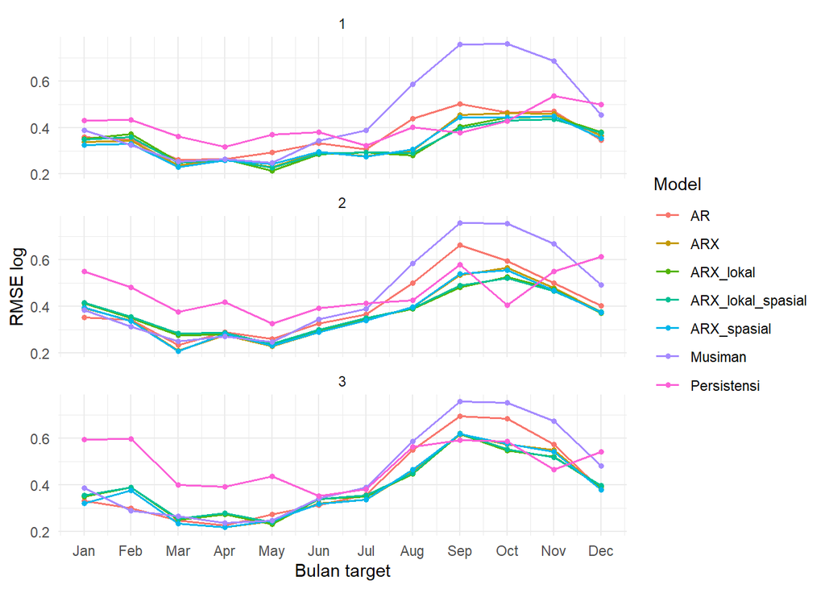

```r
ggplot(galat_bulan, aes(bulan, RMSE_log, colour = model)) +
  geom_line(linewidth = 0.6) +
  geom_point(size = 1.3) +
  facet_wrap(~ horizon, ncol = 1) +
  scale_x_continuous(breaks = 1:12, labels = month.abb) +
  labs(x = "Bulan target", y = "RMSE log", colour = "Model")
```

Jika selisih rata-rata kecil tetapi beberapa grid atau bulan jauh lebih buruk, jangan memilih model hanya dari satu RMSE gabungan. Baca `galat_menurut_grid_v2.csv` dan `galat_menurut_bulan_v2.csv` sebelum menyepakati satu model untuk seluruh wilayah.

# Moran’s I Residual Validasi

```r
set.seed(20261014)
residual_moran <- prediksi_panjang %>%
  filter(model %in% c("AR", "ARX", "ARX_spasial",
                      "ARX_lokal", "ARX_lokal_spasial")) %>%
  transmute(horizon, model, target_month, grid_id, residual = residu_log) %>%
  group_by(horizon, model, target_month) %>%
  group_modify(~ moran_one(.x, "residual", nsim = 99)) %>%
  ungroup()

ringkasan_residual <- residual_moran %>%
  group_by(horizon, model) %>%
  summarise(median_moran = median(moran_i, na.rm = TRUE),
            bulan_positif_signifikan = mean(moran_i > 0 & p_value < 0.05,
                                           na.rm = TRUE),
            .groups = "drop")

write_csv(residual_moran, file.path(TABLE_DIR, "moran_residual_v2.csv"))
knitr::kable(ringkasan_residual, digits = 3)
```

| horizon | model | median_moran | bulan_positif_signifikan |
| --- | --- | --- | --- |
| 1 | AR | 0.630 | 1 |
| 1 | ARX | 0.615 | 1 |
| 1 | ARX_lokal | 0.611 | 1 |
| 1 | ARX_lokal_spasial | 0.591 | 1 |
| 1 | ARX_spasial | 0.613 | 1 |
| 2 | AR | 0.620 | 1 |
| 2 | ARX | 0.616 | 1 |
| 2 | ARX_lokal | 0.631 | 1 |
| 2 | ARX_lokal_spasial | 0.628 | 1 |
| 2 | ARX_spasial | 0.634 | 1 |
| 3 | AR | 0.640 | 1 |
| 3 | ARX | 0.676 | 1 |
| 3 | ARX_lokal | 0.651 | 1 |
| 3 | ARX_lokal_spasial | 0.627 | 1 |
| 3 | ARX_spasial | 0.674 | 1 |

Moran’s I residual memeriksa pola spasial yang tersisa. Nilainya perlu dibaca bersama galat validasi: residual yang lebih acak tidak membenarkan model yang ramalannya lebih buruk. Nilai ini juga tidak membuktikan bahwa dinamika laut antargrid sudah dipahami.

# Keputusan Sementara

```r
for (h in 1:3) {
  d <- pasangan %>% filter(horizon == h)
  baseline <- d$acuan[d$calon == "AR"][1]
  langsung <- d %>% filter(acuan == baseline) %>%
    left_join(nilai_model %>%
                filter(horizon == h) %>%
                mutate(calon = as.character(model)) %>%
                select(calon, RMSE_log), by = "calon")
  layak <- langsung %>% filter(kuat)
  pasangan_spasial <- d %>% filter(
    (calon == "ARX_spasial" & acuan == "ARX") |
      (calon == "ARX_lokal_spasial" & acuan == "ARX_lokal")
  )
  layak <- layak %>% filter(
    !calon %in% pasangan_spasial$calon |
      pasangan_spasial$kuat[match(calon, pasangan_spasial$calon)] %in% TRUE
  )

  cat("\n### ", h, " bulan\n\n", sep = "")
  if (nrow(layak) == 0) {
    cat("**Kandidat awal: ", baseline,
        "**. Belum ada model kompleks yang mengalahkan pembanding sederhana menurut aturan screening.\n\n",
        sep = "")
  } else {
    kandidat <- layak %>% arrange(RMSE_log) %>% slice(1) %>% pull(calon)
    cat("**Kandidat awal: ", kandidat,
        "**. Model ini lolos pemeriksaan terhadap baseline pada validasi; jika memakai lag spasial, tambahan spasial juga lolos terhadap versi tanpa lag. Keputusan akhir tetap menunggu evaluasi 2023–2025.\n\n",
        sep = "")
  }
}
```

### 1 bulan

**Kandidat awal: ARX_lokal**. Model ini lolos pemeriksaan terhadap baseline pada validasi; jika memakai lag spasial, tambahan spasial juga lolos terhadap versi tanpa lag. Keputusan akhir tetap menunggu evaluasi 2023–2025.

### 2 bulan

**Kandidat awal: ARX_lokal**. Model ini lolos pemeriksaan terhadap baseline pada validasi; jika memakai lag spasial, tambahan spasial juga lolos terhadap versi tanpa lag. Keputusan akhir tetap menunggu evaluasi 2023–2025.

### 3 bulan

**Kandidat awal: ARX**. Model ini lolos pemeriksaan terhadap baseline pada validasi; jika memakai lag spasial, tambahan spasial juga lolos terhadap versi tanpa lag. Keputusan akhir tetap menunggu evaluasi 2023–2025.

Keputusan per horizon dapat berbeda. Aturan di atas hanya menentukan kandidat untuk pemodelan berikutnya; jangan memakai hasil validasi 2021–2022 sebagai akurasi akhir. Setelah spesifikasi dan penanganan missing disepakati, evaluasi sekali pada 2023–2025 dengan nilai Chl-a yang benar-benar teramati.